# Biostat 200C Homework 4

Due May 12 @ 11:59PM

Cyrene Arputhasamy

```r
library(faraway)
library(dplyr)
```

## Q1. ELMR Excercise 7.5 (p150)

The `debt` data arise from a large postal survey on the psychology of debt. The frequency of credit card use is a three-level factor ranging from `never`, through `occasionally` to `regularly`.

### 5a

Declare the response as an ordered factor and make a plot showing the relationship to `prodebt`. Comment on the plot. Use a table or plot to display the relationship between the response and the income group.

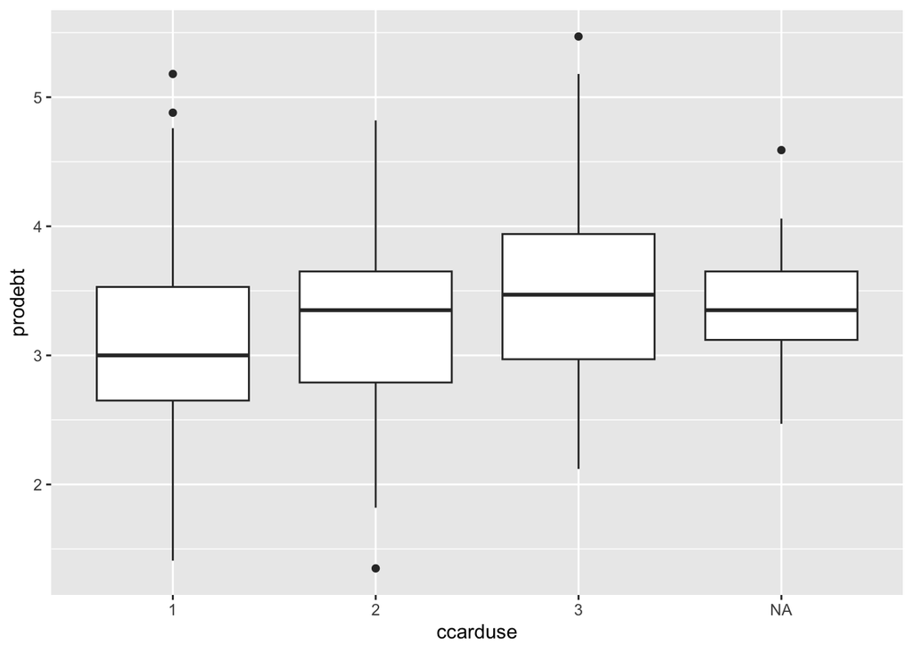

```r
debt$ccarduse <- ordered(debt$ccarduse, levels = c(1, 2, 3))
library(ggplot2)
ggplot(debt, aes(x = ccarduse, y = prodebt)) + geom_boxplot()
```

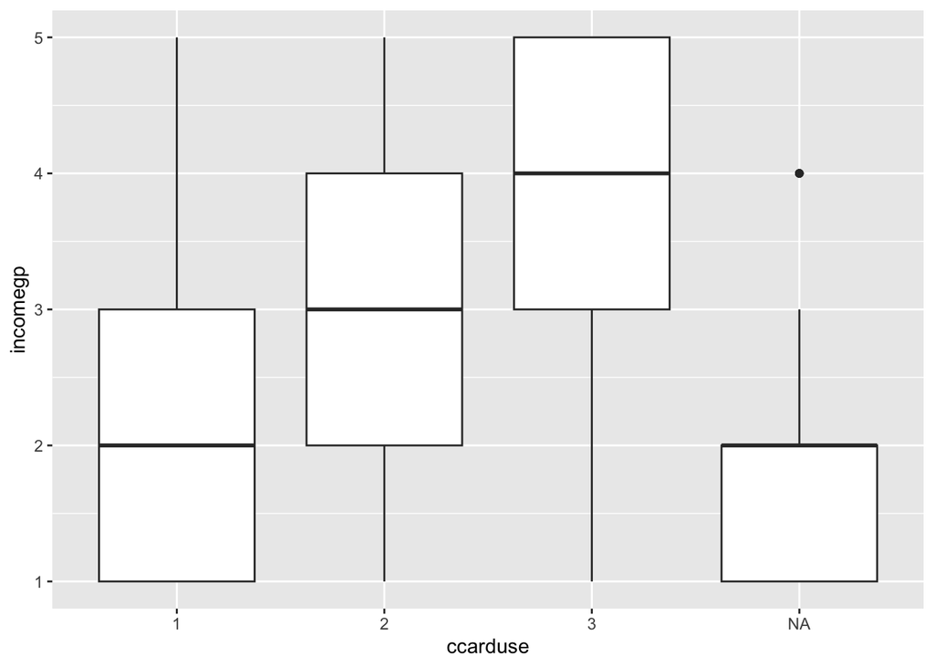

```r
ggplot(debt, aes(x = ccarduse, y = incomegp)) + geom_boxplot()
```

```r
debt %>%
  xtabs( ~ ccarduse + incomegp, .)
```

```
##         incomegp
## ccarduse  1  2  3  4  5
##        1 64 60 46 24 26
##        2 10 27 18 21 25
##        3  4 13 18 20 38
```

There is a little variability in `prodebt` across groups of card use. There is a general trend that those scoring high in `prodebt`, having a general favorable attitude to debt, score higher in credit card use. It also seems that those with high credit card use are generally in higher income groups.

### 5b

Fit a proportional odds model for credit card use with all the other variables as predictors. What are the two most significant predictors (largest t-values) and what is their qualitative effect on the response? What is the least significant predictor?

```r
library(MASS)
pocc <- polr(ccarduse ~ ., data = debt)
summary(pocc)
```

```
##
## Re-fitting to get Hessian
```

```
## Call:
## polr(formula = ccarduse ~ ., data = debt)
##
## Coefficients:
##             Value Std. Error t value
## incomegp  0.47131     0.1061  4.4423
## house     0.11600     0.2324  0.4992
## children -0.07872     0.1250 -0.6296
## singpar   0.88172     0.5971  1.4766
## agegp     0.20568     0.1576  1.3050
## bankacc   2.10270     0.5934  3.5435
## bsocacc   0.47322     0.2671  1.7715
## manage    0.18179     0.1653  1.0998
## cigbuy   -0.73546     0.2981 -2.4674
## xmasbuy   0.47014     0.4130  1.1385
## locintrn  0.11881     0.1424  0.8344
## prodebt   0.61046     0.1822  3.3497
##
## Intercepts:
##     Value   Std. Error t value
## 1|2  7.9694  1.4752     5.4023
## 2|3  9.3944  1.5051     6.2417
##
## Residual Deviance: 511.673
## AIC: 539.673
## (160 observations deleted due to missingness)
```

```r
exp(pocc$coef[1])
```

```
## incomegp
## 1.602096
```

```r
exp(pocc$coef[6])
```

```
##  bankacc
## 8.188214
```

The two most significant predictors are `incomegp` (income group) and `bankacc` (whether or not the respondent has a bank account). The least significant predictor is `house` (the security of housing tenure). The odds of moving from `never` to `occassional` credit card use **or** from `occasional` to `regularly` using a credit card increases by a factor of 1.6 $(e^{0.47131})$ when income group increases one level. The odds of moving from `never` to `occassional` credit card use **or** from `occasional` to `regularly` using a credit card increases by a factor of 8.18 when an individual has a bank account as compared to not having a bank account.

### 5c

Fit a proportional odds model using only the least significant predictor from the previous model. What is the significance of this predictor in this small model? Are the conclusions regarding this predictor contradictory for the two models?

```r
pocc2 <- polr(ccarduse ~ house, data = debt)
summary(pocc2)
```

```
##
## Re-fitting to get Hessian
```

```
## Call:
## polr(formula = ccarduse ~ house, data = debt)
##
## Coefficients:
##       Value Std. Error t value
## house 0.558     0.1433   3.895
##
## Intercepts:
##     Value  Std. Error t value
## 1|2 1.3000 0.3118     4.1698
## 2|3 2.4670 0.3274     7.5344
##
## Residual Deviance: 847.2661
## AIC: 853.2661
## (36 observations deleted due to missingness)
```

```r
pt(3.895, 3, lower.tail = FALSE)
```

```
## [1] 0.01501047
```

The significance of this predictor now has a p-value of 0.01 which is significant. This is contradictory to the previous model.

### 5d

Use stepwise AIC to select a smaller model than the full set of predictors. You will need to handle the missing values carefully. Report on the qualitative effect of the predictors in your chosen model. Can we conclude that the predictors that were dropped from the model have no relation to the response?

```r
library(tidyverse)
debt2 <- debt %>% drop_na()
poccf <- polr(ccarduse ~ ., data = debt2)
(poccf2 <- step(poccf, trace = FALSE))
```

```
## Call:
## polr(formula = ccarduse ~ incomegp + agegp + bankacc + bsocacc +
##     cigbuy + prodebt, data = debt2)
##
## Coefficients:
##   incomegp      agegp    bankacc    bsocacc     cigbuy    prodebt
##  0.4588585  0.2695623  2.0815757  0.5047742 -0.7677124  0.5635449
##
## Intercepts:
##      1|2      2|3
## 5.994399 7.394820
##
## Residual Deviance: 517.5895
## AIC: 533.5895
```

By step-wise AIC selection, six variables were dropped. The odds of moving from `never` to `occassional` credit card use **or** from `occasional` to `regularly` using a credit card increases by a factor of exp(0.4588585) = 1.58 when moving up one group in `incomegp`. The odds of moving from one level of credit card use to the next increases by a factor of exp(0.2695623) = 1.309391 when `agegp` increases. Having a bank account (`bankacc`) increases the odds of moving from one level of credit card use to the next by a factor of exp(2.0815757) = 8.01 times. The odds of moving from one level of credit card use to the next increases by a factor of exp(0.5047742) = 1.65 when the responded has a building society account (`bsocacc`). Buying cigarettes (`cigbuy`) decreases the odds of moving from one level of credit card use to the next by a factor of exp(-0.7677124) = 0.4640735 or decreases by 54%. Scoring higher on the scale of attitude toward debt increases the odds of moving from one level of credit card use to the next by a factor of exp(0.5635449) = 1.756889. This does not mean that the predictors dropped from the model have no relation to the response.

### 5e

Compute the median values of the predictors in your selected model. At these median values, contrast the predicted outcome probabilities for both smokers and nonsmokers.

```r
debt2 %>%
  dplyr::select(incomegp, agegp, bankacc, bsocacc, cigbuy, prodebt) %>%
  apply(., 2, median)
```

```
## incomegp    agegp  bankacc  bsocacc   cigbuy  prodebt
##     3.00     2.00     1.00     1.00     0.00     3.18
```

```r
predict(poccf2, data.frame(incomegp = 3, agegp = 2, bankacc = 1, bsocacc = 1, cigbuy = 0, prodebt = 3.18), type = "probs")
```

```
##         1         2         3
## 0.4256250 0.3247658 0.2496092
```

```r
predict(poccf2, data.frame(incomegp = 3, agegp = 2, bankacc = 1, bsocacc = 1, cigbuy = 1, prodebt = 3.18), type = "probs")
```

```
##         1         2         3
## 0.6149076 0.2513666 0.1337258
```

The predicted outcome probabilities for never using a credit card (level 1) is .42 for non smokers and .61 for smokers. The predicted probability of occasionally using a credit card is lower for smokers than non-smokers at .25 compared to .32. The predicted probability of regularly using a credit card is .24 for non-smokers and .13 for smokers.

### 5f

Fit a proportional hazards model to the same set of predictors and recompute the two sets of probabilities from the previous question. Does it make a difference to use this type of model?

```r
phcc <- polr(ccarduse ~ incomegp + agegp + bankacc + bsocacc + cigbuy + prodebt, method = "cloglog", data = debt2)
predict(phcc, data.frame(incomegp = 3, agegp = 2, bankacc = 1, bsocacc = 1, cigbuy = 0, prodebt = 3.18), type = "probs")
```

```
##         1         2         3
## 0.4491074 0.2946605 0.2562321
```

```r
predict(phcc, data.frame(incomegp = 3, agegp = 2, bankacc = 1, bsocacc = 1, cigbuy = 1, prodebt = 3.18), type = "probs")
```

```
##         1         2         3
## 0.5571469 0.2872181 0.1556350
```

Fitting the model as a proportional hazards model only slightly changed the predicted probabilities in this example. It doesn’t seem to make a difference to use this type of model.

## Q2. Moments of exponential family distributions

Show that the exponential family distributions have moments
$$\begin{eqnarray*}
\mathbb{E}Y &=& \mu = b'(\theta) \\
\operatorname{Var}Y &=& \sigma^2 = b''(\theta)
a(\phi).
\end{eqnarray*}$$

Mean:
$$\begin{eqnarray*}
\mathbb{E}Y = \int y f(y|\theta,\phi)dy \\
\frac{d}{d\theta} f(y|\theta,\phi) = \frac{y -
b'(\theta)}{a(\phi)}f(y|\theta, \phi) \\
\int\frac{d}{d\theta} f(y|\theta,\phi)dy = \frac{1}{a(\phi)}[\mathbb{E}Y
- b'(\theta)] = 0 \\
\mathbb{E}Y - b'(\theta) = ) \\
\mathbb{E}Y = b'(\theta)
\end{eqnarray*}$$

Variance:
$$\begin{eqnarray*}
\int\frac{d^2}{d\theta^2}f(y|\theta,\phi)dy = 0 \\
\frac{d^2}{d\theta^2}f(y|\theta,\phi) =
-\frac{b''(\theta)}{a(\phi)}f(y|\theta,\phi) + [\frac{y -
b'(\theta)}{a(\phi)}]^2 f(y|\theta,\phi) \\
\int\frac{d^2}{d\theta^2}f(y|\theta,\phi)dy = \int
(-\frac{b''(\theta)}{a(\phi)}f(y|\theta,\phi) + [\frac{y -
b'(\theta)}{a(\phi)}]^2 f(y|\theta,\phi))dy = 0 \\
-\frac{b''(\theta)}{a(\phi)}f(y|\theta,\phi) +
\frac{1}{(a(\phi))^2} \operatorname{Var}Y = 0 \\
\frac{b''(\theta)}{a(\phi)}f(y|\theta,\phi) =
\frac{\operatorname{Var}Y}{(a(\phi))^2} \\
\operatorname{Var}Y = b''(\theta)a(\phi) \\
\end{eqnarray*}$$

## Q3. Score and information matrix of GLM

Derive the gradient (score), negative Hessian, and Fisher information matrix (expected negative Hessian) of GLM.

For GLM,
$$\begin{eqnarray*}
\ell(\boldsymbol{\beta}) &=& \sum_{i=1}^n \frac{y_i \theta_i -
b(\theta_i)}{a(\phi)} + c(y_i, \phi) \\
\end{eqnarray*}$$

The gradient (score) is,
$$\begin{eqnarray*}
\nabla \ell_i(\boldsymbol{\beta}) &=& \frac{y_i -
b'(\theta_i)}{a(\phi)} \nabla_{\boldsymbol{\beta}} \theta_i \\
&=& \frac{y_i - b'(\theta_i)}{a(\phi)} \cdot
\frac{d\theta_i}{d\mu_i} \cdot \nabla_{\boldsymbol{\beta}} \mu_i.
\end{eqnarray*}$$

because
$$\begin{eqnarray*}
\mathbb{E}Y_i = \mu_i = b'(\theta_i)
\frac{d \mu_i}{d \theta_i} = b''(\theta_i)
\end{eqnarray*}$$

rearranging gives
$$\begin{eqnarray*}
\frac{d \theta_i}{d \mu_i} = \frac{1}{b''(\theta_i)}
\end{eqnarray*}$$

And since for GLM
$$\begin{eqnarray*}
g(\mu_i) = \mathbf{x}_i^T\beta = \eta_i
\mu_i(\eta_i) = g^{-1}(\eta_i)
\frac{d \mu_i}{d \eta_i} = \mu_i'(\eta_i)
\end{eqnarray*}$$

Furthermore,
$$\begin{eqnarray*}
\eta_i = \mathbf{x}_i^T\beta
\frac{d \eta_i}{d \beta_i} = \mathbf{x}_i
\end{eqnarray*}$$

Combining all these parts and using the chain rule,
$$\begin{eqnarray*}
\frac{d \ell}{d \beta} &=& \frac{d \ell}{d \theta_i} \cdot
\frac{d theta_i}{d \mu_i} \cdot \frac{d mu_i}{d \eta_i} \cdot \frac{d
\eta_i}{d \beta} \\
\nabla \ell_i(\boldsymbol{\beta}) &=& \frac{y_i -
b'(\theta_i)}{a(\phi)} \cdot \frac{1}{b''(\theta_i)} \cdot
\mu_i'(\eta_i) \cdot \mathbf{x}_i \\
&=& \frac{(y_i - \mu_i)
\mu_i'(\eta_i)}{\sigma_i^2}\mathbf{x}_i
\end{eqnarray*}$$

because
$$\begin{eqnarray*}
\mu = b'(\theta)
\operatorname{Var}Y &=& \sigma^2 = b''(\theta) a(\phi)
\end{eqnarray*}$$

For the Hessian,
$$\begin{eqnarray*}
\nabla_\beta^2(\ell) &=& \sum_i[\frac{y_i - \mu_i}{\sigma_i^2}
\mu_i'(\eta_i)\mathbf{x}_i]' \\
&=& \sum_i [\frac{y_i -
\mu_i}{\sigma_i^2}\mu_i'(\eta_i)]'x_i x_i^T \\
&=& \sum_i [ (\frac{y_i - \mu_i}{\sigma_i^2})'
\mu_i'(\eta_i) + (\frac{y_i -
\mu_i}{\sigma_i^2})(\mu_i'(\eta_i))'] x_i x_i^T \\
[ (\frac{y_i - \mu_i}{\sigma_i^2})' = \frac{(y_i -
\mu_i)'\sigma_i^2 - (y_i - \mu_i)(\sigma_i^2)'}{(\sigma_i^2)^2}
\\
= \frac{-\mu_i(\eta_i)\sigma_i^2 - (y_i - \mu_i) \frac{d \sigma_i^2}{d
\mu_i} \mu_i'(\eta_i)}{\sigma_i^4} ] \\
\Rightarrow &=& \sum_i{\frac{-\mu_i(\eta_i)\sigma_i^2 - (y_i -
\mu_i) \frac{d \sigma_i^2}{d \mu_i} \mu_i'(\eta_i)}{\sigma_i^4}
\mu_i'(\eta_i) + \frac{y_i -
\mu_i}{\sigma_i^2}\mu_i''(\eta_i)} x+i x_i^T \\
&=& - \sum_i [\frac{-[\mu_i'(\eta_i)]^2}{\sigma_i^2} +
\frac{-(y_i - \mu_i)
\frac{d\sigma_i^2}{d\mu_i}[\mu_i'(\eta_i)]^2}{\sigma_i^4} +
\frac{(y_i - \mu_i)\mu_i''(\eta_i)}{\sigma_i^2}] x_i x_i^T
\end{eqnarray*}$$

The Fisher Information matrix is the negative of the above result of the Hessian.

## Q4. ELMR Exercise 8.1 (p171)

Data is generated from the exponential distribution with density $f(y) = \lambda e^{-\lambda y}$ where $\lambda, y > 0$.

### 1a

Identify the specific form of $\theta, \phi, a() , b()$ and $c()$ for the exponential distribution.

The exponential distribution is a special case of the gamma distribution.
$$\begin{eqnarray*}
f(y) = e^{- \lambda y + \log{\lambda}}
\end{eqnarray*}$$
so
$$\begin{eqnarray*}
\theta = - \lambda, b(\theta) = - \log\lambda = -\log(-\theta) \\
\phi = 1, a(\phi) = 1, c(y, \phi) = 0
\end{eqnarray*}$$

### 1b

What is the canonical link and variance function for a GLM with a response following the exponential distribution?
$$\begin{eqnarray*}
b'(\theta) = \frac{d}{d \theta} [- \log(- \theta)] =
-\frac{1}{\theta} \\
\mathbb{E}Y = -\frac{1}{\theta} = \frac{1}{\lambda} = \mu
\end{eqnarray*}$$
The canonical form expresses $\theta$ as a function of $\mu$ so $\theta(\mu) = -\frac{1}{\mu}$
$$\begin{eqnarray*}
\operatorname{Var}Y &=& b''(\theta) a(\phi) = \frac{d}{d
\theta} [- \frac{1}{\theta}] = \frac{1}{\theta^2} = \mu^2
\end{eqnarray*}$$

### 1c

Identify a practical difficulty that may arise when using the canonical link in this instance.

In this case, modeling the canonical link as a linear combination of predictors can result in a negative mean.

### 1d

When comparing nested models in this case, should an F or $\chi^2$ test be used? Explain.

The dispersion parameter $\phi = 1$. We can compare the models using the deviance test with $\chi^2$ as the reference distribution. The F test is used when the dispersion is estimated, but in this case we know the dispersion.

### 1e

Express the deviance in this case in terms of the responses $y_i$ and the fitted values $\hat{\mu}_i$.

$$\begin{eqnarray*}
D &=& 2 \sum(\frac{y_i-\hat{\mu}_i}{\hat{\mu}_i} -
\log\frac{y_i}{\hat{\mu}_i})
\end{eqnarray*}$$

## Q5. ELMR Exercise 8.4 (p172)

Consider the Galápagos data (`gala`) and model analyzed in this chapter. The purpose of this question is to reproduce the details of the GLM fitting of this data.

### 4a

Fit a Poisson model to the species response with the five geographic variables as predictors. Do not use the endemics variable. Report the values of the coefficients and the deviance.

```r
pm <- glm(Species ~ . - Endemics, family = poisson, data = gala)
summary(pm)
```

```
##
## Call:
## glm(formula = Species ~ . - Endemics, family = poisson, data = gala)
##
## Deviance Residuals:
##     Min       1Q   Median       3Q      Max
## -8.2752  -4.4966  -0.9443   1.9168  10.1849
##
## Coefficients:
##               Estimate Std. Error z value Pr(>|z|)
## (Intercept)  3.155e+00  5.175e-02  60.963  < 2e-16 ***
## Area        -5.799e-04  2.627e-05 -22.074  < 2e-16 ***
## Elevation    3.541e-03  8.741e-05  40.507  < 2e-16 ***
## Nearest      8.826e-03  1.821e-03   4.846 1.26e-06 ***
## Scruz       -5.709e-03  6.256e-04  -9.126  < 2e-16 ***
## Adjacent    -6.630e-04  2.933e-05 -22.608  < 2e-16 ***
## ---
## Signif. codes:  0 '***' 0.001 '**' 0.01 '*' 0.05 '.' 0.1 ' ' 1
##
## (Dispersion parameter for poisson family taken to be 1)
##
##     Null deviance: 3510.73  on 29  degrees of freedom
## Residual deviance:  716.85  on 24  degrees of freedom
## AIC: 889.68
##
## Number of Fisher Scoring iterations: 5
```

### 4b

For a Poisson GLM, derive $\eta$, $d\eta /dμ$, V(μ) and the weights to be used in an iteratively fit GLM. What is the form of the adjusted dependent variable here?

$$\begin{eqnarray*}
\eta = \log\mu \\
\frac{d \eta}{d \mu} = \frac{1}{\mu} \\
V(\mu) = \mu \\
\frac{1}{w} = (\frac{d\eta}{d\mu})^2 V(\hat{\mu}^{<0>}) \\
= (\frac{1}{\mu})^2 \cdot \mu = \frac{1}{\mu} \\
w = \mu
z^i = \hat{\eta}^i + (y - \hat{\mu}^i)\frac{d\eta}{d\mu}
= \log\hat{\mu} + \frac{(y - \hat{\mu})}{\mu}
\end{eqnarray*}$$

### 4c

Using the observed response as initial values, compute the first stage of the iteration, stopping after the first linear model fit. Compare the coefficients of this linear model to those found in the GLM fit. How close are they?

```r
gala %>% nrow()
```

```
## [1] 30
```

```r
# First iteration
y <- gala$Species/30; mu <- y
eta <- log(mu)
z <- eta + (y-mu)/mu
w <- mu
lmod <- lm(z ~ . - Endemics - Species, weights = w, gala)
coef(lmod)
```

```
##   (Intercept)          Area     Elevation       Nearest         Scruz
##  0.1179571596 -0.0005298484  0.0031643557  0.0025188990 -0.0037899780
##      Adjacent
## -0.0006623523
```

```r
deviance(lmod)
```

```
## [1] 19.22692
```

### 4d

Continue the iteration to get the next $\eta$ and μ. Use this to compute the current value of the deviance. How close is this to the deviance from the GLM?

```r
#Second Iteration
eta <- lmod$fitted.values
mu <- exp(eta)
z <- eta + (y-mu)/mu
w <- mu
lmod <- lm(z ~ . - Endemics - Species, weights = w, gala)
coef(lmod)
```

```
##   (Intercept)          Area     Elevation       Nearest         Scruz
## -0.1909379370 -0.0005651969  0.0034606226  0.0077171134 -0.0052400871
##      Adjacent
## -0.0006604828
```

```r
deviance(lmod)
```

```
## [1] 19.03216
```

The deviance of this model is much lower than that of the GLM and is closer to the degrees of freedom.

### 4e

Compute one more iteration of the GLM fit, reporting the next calculation of the coefficients and deviance. How close are these to target now?

```r
# Third Iteration
eta <- lmod$fitted.values
mu <- exp(eta)
z <- eta + (y-mu)/mu
w <- mu
lmod <- lm(z ~ . - Endemics - Species, weights = w, gala)
coef(lmod)
```

```
##   (Intercept)          Area     Elevation       Nearest         Scruz
## -0.2449391271 -0.0005793855  0.0035379237  0.0087861184 -0.0056868875
##      Adjacent
## -0.0006630167
```

```r
deviance(lmod)
```

```
## [1] 24.18368
```

These values are yet closer to the target.

### 4f

Repeat these iterations a few more times,computing the deviance in each time. Stop when the deviance does not change much. Compare your final estimated coefficients to that produced by the GLM fit.

```r
# Fourth Iteration
eta <- lmod$fitted.values
mu <- exp(eta)
z <- eta + (y-mu)/mu
w <- mu
lmod <- lm(z ~ . - Endemics - Species, weights = w, gala)
coef(lmod)
```

```
##   (Intercept)          Area     Elevation       Nearest         Scruz
## -0.2463883185 -0.0005799422  0.0035405910  0.0088255087 -0.0057093801
##      Adjacent
## -0.0006630313
```

```r
deviance(lmod)
```

```
## [1] 25.35666
```

```r
# Fifth Iteration
eta <- lmod$fitted.values
mu <- exp(eta)
z <- eta + (y-mu)/mu
w <- mu
lmod <- lm(z ~ . - Endemics - Species, weights = w, gala)
coef(lmod)
```

```
##   (Intercept)          Area     Elevation       Nearest         Scruz
## -0.2463895038 -0.0005799429  0.0035405940  0.0088255719 -0.0057094223
##      Adjacent
## -0.0006630311
```

```r
deviance(lmod)
```

```
## [1] 25.39925
```

The deviance and coefficients are no longer changing after the 4th iteration. The estimated intercept is quite different, even a different sign, but the coefficients of the predictors are almost exactly the same as the GLM estimates.

### 4g

Use your final iterated linear model fit to produce standard errors for the coefficients. How close are these to that produced by the direct GLM fit?

```r
sqrt(diag(vcov(lmod)))
```

```
##  (Intercept)         Area    Elevation      Nearest        Scruz     Adjacent
## 0.2915893909 0.0001480385 0.0004925063 0.0102621268 0.0035251372 0.0001652498
```

The standard error was lower for all the estimated coefficients in the GLM. They’re off by an order of roughly 10.

## Q6. ELMR Exercise 8.5 (p172)

Again using the Galápagos data, fit a Poisson model to the species response with the five geographic variables as predictors. Do not use the endemics variable. The purpose of this question is to compare six different ways of testing the significance of the elevation predictor, i.e., $H_0 : \beta_{Elev} = 0$. In each case, report the p-value.

### 5a

Use the z-statistic from the model summary.

```r
summary(pm)
```

```
##
## Call:
## glm(formula = Species ~ . - Endemics, family = poisson, data = gala)
##
## Deviance Residuals:
##     Min       1Q   Median       3Q      Max
## -8.2752  -4.4966  -0.9443   1.9168  10.1849
##
## Coefficients:
##               Estimate Std. Error z value Pr(>|z|)
## (Intercept)  3.155e+00  5.175e-02  60.963  < 2e-16 ***
## Area        -5.799e-04  2.627e-05 -22.074  < 2e-16 ***
## Elevation    3.541e-03  8.741e-05  40.507  < 2e-16 ***
## Nearest      8.826e-03  1.821e-03   4.846 1.26e-06 ***
## Scruz       -5.709e-03  6.256e-04  -9.126  < 2e-16 ***
## Adjacent    -6.630e-04  2.933e-05 -22.608  < 2e-16 ***
## ---
## Signif. codes:  0 '***' 0.001 '**' 0.01 '*' 0.05 '.' 0.1 ' ' 1
##
## (Dispersion parameter for poisson family taken to be 1)
##
##     Null deviance: 3510.73  on 29  degrees of freedom
## Residual deviance:  716.85  on 24  degrees of freedom
## AIC: 889.68
##
## Number of Fisher Scoring iterations: 5
```

```r
summary(pm)$coefficients[,4]
```

```
##   (Intercept)          Area     Elevation       Nearest         Scruz
##  0.000000e+00 5.651952e-108  0.000000e+00  1.260641e-06  7.106220e-20
##      Adjacent
## 3.632171e-113
```

```r
pnorm(summary(pm)$coefficients[,3], lower.tail = FALSE)
```

```
##  (Intercept)         Area    Elevation      Nearest        Scruz     Adjacent
## 0.000000e+00 1.000000e+00 0.000000e+00 6.303205e-07 1.000000e+00 1.000000e+00
```

The p-value for `Elevation` is essentially 0 and thus is significant.

### 5b

Fit a model without elevation and use the difference in deviances to make the test.

```r
pm2 <- glm(Species ~ . - Endemics - Elevation, family = poisson, data = gala)
summary(pm2)
```

```
##
## Call:
## glm(formula = Species ~ . - Endemics - Elevation, family = poisson,
##     data = gala)
##
## Deviance Residuals:
##     Min       1Q   Median       3Q      Max
## -11.800   -8.539   -3.862    2.210   23.400
##
## Coefficients:
##               Estimate Std. Error z value Pr(>|z|)
## (Intercept)  4.345e+00  3.114e-02 139.535   <2e-16 ***
## Area         4.190e-04  1.204e-05  34.793   <2e-16 ***
## Nearest      2.081e-02  1.700e-03  12.239   <2e-16 ***
## Scruz       -6.781e-03  5.456e-04 -12.427   <2e-16 ***
## Adjacent    -2.564e-06  2.939e-05  -0.087     0.93
## ---
## Signif. codes:  0 '***' 0.001 '**' 0.01 '*' 0.05 '.' 0.1 ' ' 1
##
## (Dispersion parameter for poisson family taken to be 1)
##
##     Null deviance: 3510.7  on 29  degrees of freedom
## Residual deviance: 2389.6  on 25  degrees of freedom
## AIC: 2560.4
##
## Number of Fisher Scoring iterations: 6
```

```r
pchisq(deviance(pm2) - deviance(pm), pm$df - pm2$df, lower = F)
```

```
## numeric(0)
```

### 5c

Use the Pearson Chi-squared statistic in place of the deviance in the previous test.

```r
px2 <- sum(residuals(pm, type = "pearson")^2)
pchisq(px2, pm$df.residual, lower.tail = FALSE)
```

```
## [1] 2.18719e-145
```

The small p-value indicates that the model doesn’t fit the data well.

```r
px2.1 <- sum(residuals(pm2, type = "pearson")^2)
pchisq(px2.1, pm2$df.residual, lower.tail = FALSE)
```

```
## [1] 0
```

The model without `Elevation` has an even smaller p-value than with `Elevation` so the model without `Elevation` fits worse than when it is included in the model.

### 5d

Fit the Poisson model with a free dispersion parameter as described in Section 5.2. Make the test using the model summary.

```r
dp <- sum(residuals(pm, type = "pearson")^2)/pm$df.residual
dp2 <- sum(residuals(pm2, type = "pearson")^2)/pm2$df.residual
summary(pm, dispersion = dp)
```

```
##
## Call:
## glm(formula = Species ~ . - Endemics, family = poisson, data = gala)
##
## Deviance Residuals:
##     Min       1Q   Median       3Q      Max
## -8.2752  -4.4966  -0.9443   1.9168  10.1849
##
## Coefficients:
##               Estimate Std. Error z value Pr(>|z|)
## (Intercept)  3.1548079  0.2915897  10.819  < 2e-16 ***
## Area        -0.0005799  0.0001480  -3.918 8.95e-05 ***
## Elevation    0.0035406  0.0004925   7.189 6.53e-13 ***
## Nearest      0.0088256  0.0102621   0.860    0.390
## Scruz       -0.0057094  0.0035251  -1.620    0.105
## Adjacent    -0.0006630  0.0001653  -4.012 6.01e-05 ***
## ---
## Signif. codes:  0 '***' 0.001 '**' 0.01 '*' 0.05 '.' 0.1 ' ' 1
##
## (Dispersion parameter for poisson family taken to be 31.74914)
##
##     Null deviance: 3510.73  on 29  degrees of freedom
## Residual deviance:  716.85  on 24  degrees of freedom
## AIC: 889.68
##
## Number of Fisher Scoring iterations: 5
```

```r
summary(pm2, dispersion = dp2)
```

```
##
## Call:
## glm(formula = Species ~ . - Endemics - Elevation, family = poisson,
##     data = gala)
##
## Deviance Residuals:
##     Min       1Q   Median       3Q      Max
## -11.800   -8.539   -3.862    2.210   23.400
##
## Coefficients:
##               Estimate Std. Error z value Pr(>|z|)
## (Intercept)  4.345e+00  3.360e-01  12.932  < 2e-16 ***
## Area         4.190e-04  1.299e-04   3.225  0.00126 **
## Nearest      2.081e-02  1.834e-02   1.134  0.25667
## Scruz       -6.781e-03  5.887e-03  -1.152  0.24941
## Adjacent    -2.564e-06  3.171e-04  -0.008  0.99355
## ---
## Signif. codes:  0 '***' 0.001 '**' 0.01 '*' 0.05 '.' 0.1 ' ' 1
##
## (Dispersion parameter for poisson family taken to be 116.4215)
##
##     Null deviance: 3510.7  on 29  degrees of freedom
## Residual deviance: 2389.6  on 25  degrees of freedom
## AIC: 2560.4
##
## Number of Fisher Scoring iterations: 6
```

`Elevation` is still significant with the free dispersion parameter.

### 5e

Use the sandwich estimation method for the standard errors in the original model. Use these to compute z-statistics.

```r
library(sandwich)
rbm <- glm(Species ~ . - Endemics, family = poisson, data = gala)
sqrt(diag(vcovHC(rbm)))
```

```
##  (Intercept)         Area    Elevation      Nearest        Scruz     Adjacent
## 0.3185550946 0.0012176343 0.0011939774 0.0228021845 0.0065382200 0.0006212657
```

```r
(zstat <- summary(rbm)$coefficients[,1]/sqrt(diag(vcovHC(rbm))))
```

```
## (Intercept)        Area   Elevation     Nearest       Scruz    Adjacent
##   9.9034921  -0.4762866   2.9653778   0.3870494  -0.8732380  -1.0672263
```

```r
pnorm(zstat, lower.tail = FALSE)
```

```
##  (Intercept)         Area    Elevation      Nearest        Scruz     Adjacent
## 2.009940e-23 6.830649e-01 1.511557e-03 3.493598e-01 8.087333e-01 8.570652e-01
```

### 5f

Use the robust GLM estimation method and report the test result from the summary.

```r
library(robust)
rbm <- glmRob(Species ~ Area +  Elevation + Nearest + Scruz + Adjacent, family = poisson, gala)
summary(rbm)
```

```
## [1] "Variance number 1 smaller than 1.e-10 (set to 1.e-10)"
## [1] "Variance number 2 smaller than 1.e-10 (set to 1.e-10)"
## [1] "Variance number 3 smaller than 1.e-10 (set to 1.e-10)"
## [1] "Variance number 4 smaller than 1.e-10 (set to 1.e-10)"
## [1] "Variance number 5 smaller than 1.e-10 (set to 1.e-10)"
## [1] "Variance number 6 smaller than 1.e-10 (set to 1.e-10)"
```

```
##
## Call: glmRob(formula = Species ~ Area + Elevation + Nearest + Scruz +
##     Adjacent, family = poisson, data = gala)
## Deviance Residuals:
##    Min     1Q Median     3Q    Max
##  55.67  67.94  89.26 147.84 191.13
##
## Coefficients:
##             Estimate Std. Error z value Pr(>|z|)
## (Intercept)  -461473          0    -Inf        0
## Area         -770990          0    -Inf        0
## Elevation       2216          0     Inf        0
## Nearest        61888          0     Inf        0
## Scruz           6748          0     Inf        0
## Adjacent       21579          0     Inf        0
##
## (Dispersion Parameter for poisson family taken to be 1 )
##
##     Null Deviance: 21190 on 29 degrees of freedom
##
## Residual Deviance: NaN on 24 degrees of freedom
##
## Number of Iterations: 50
##
## Correlation of Coefficients:
##           (Intercept) Area Elevation Nearest Scruz
## Area      NaN
## Elevation NaN         NaN
## Nearest   NaN         NaN  NaN
## Scruz     NaN         NaN  NaN       NaN
## Adjacent  NaN         NaN  NaN       NaN     NaN
```

### 5g

Compare all six results. Pick the best one and justify your choice.